# Assignment/HW5

Group 2

April 19, 2018

Overview In this homework assignment we explore, analyze, and model a data set containing information on approximately 12,000 commercially available wines. The variables are mostly related to the chemical properties of the wine being sold. The response variable is the number of sample cases of wine that were purchased by wine distribution companies after sampling a wine. These cases would be used to provide tasting samples to restaurants and wine stores around the United States. The more sample cases purchased, the more likely is a wine to be sold at a high end restaurant.

A large wine manufacturer is studying the data in order to predict the number of wine cases ordered based upon the wine characteristics. If the wine manufacturer can predict the number of cases, then it will be able to adjust their wine offering to maximize sales.

Our objective is to build a count regression model to predict the number of cases of wine that will be sold given certain properties of the wine.

```r
library(psych)
library(tidyverse)
library(knitr)
library(ggplot2)
library(reshape2)
library(DataExplorer)
#library(usdm)
```

```r
variable_names <- c("Index", "Target", "AcidIndex", "Alcohol", "Chlorides",
                    "CitricAcid", "Density", "FixedAcidity", "FreeSulfurDioxide", "LabelAppeal",
                    "ResidualSugar", "Stars", "Sulphates", "TotalSulfurDioxide", "VolatileAcidity", "pH")

description <- c("Identification Variable (do not use)",
                   "Number of cases purchased",
                   "Proprietary method of testing ottal acidity of wine by using a weighted average",
                   "Alcohol content",
                   "Chloride content of wine",
                   "Citric acid content",
                   "Density of wine",
                   "Fixed acidity of wine",
                   "Sulfur dioxide content of wine",
                   "Marketing score indidcating appeal of label design for consumers. Positive is like, negative is dislike",
                   "Resdiual sugar of wine",
                   "Wine rating by a team of experts. 4 stars = Excellent, 1 star = Poor",
                   "Sulfate content of wine",
                   "Total sulfur dioxide of wine",
                   "Volatile acid content of wine",
                   "pH of wine")

variable_type <-c("Predictor", "Response", "Predictor", "Predictor", "Predictor",
                  "Predictor", "Predictor", "Predictor", "Predictor", "Predictor",
                  "Predictor", "Predictor", "Predictor",  "Predictor",  "Predictor",  "Predictor")

data_type <- c("quantitative", "quantitative", "quantitative", "quantitative", "quantitative",
               "quantitative", "quantitative", "quantitative", "quantitative", "categorical",
               "quantitative", "categorical", "quantitative", "quantitative", "quantitative", "quantitative")

wine_descriptions <- cbind.data.frame(variable_names, description, variable_type, data_type)

colnames(wine_descriptions) <- c("Variable Name", "Description", "Variable Type", "Data Type")

kable(wine_descriptions)
```

| Variable Name | Description | Variable Type | Data Type |
| --- | --- | --- | --- |
| Index | Identification Variable (do not use) | Predictor | quantitative |
| Target | Number of cases purchased | Response | quantitative |
| AcidIndex | Proprietary method of testing ottal acidity of wine by using a weighted average | Predictor | quantitative |
| Alcohol | Alcohol content | Predictor | quantitative |
| Chlorides | Chloride content of wine | Predictor | quantitative |
| CitricAcid | Citric acid content | Predictor | quantitative |
| Density | Density of wine | Predictor | quantitative |
| FixedAcidity | Fixed acidity of wine | Predictor | quantitative |
| FreeSulfurDioxide | Sulfur dioxide content of wine | Predictor | quantitative |
| LabelAppeal | Marketing score indidcating appeal of label design for consumers. Positive is like, negative is dislike | Predictor | categorical |
| ResidualSugar | Resdiual sugar of wine | Predictor | quantitative |
| Stars | Wine rating by a team of experts. 4 stars = Excellent, 1 star = Poor | Predictor | categorical |
| Sulphates | Sulfate content of wine | Predictor | quantitative |
| TotalSulfurDioxide | Total sulfur dioxide of wine | Predictor | quantitative |
| VolatileAcidity | Volatile acid content of wine | Predictor | quantitative |
| pH | pH of wine | Predictor | quantitative |

The data were loaded into a Github repository for better reproducability.

```r
wine_data <- read.csv("https://raw.githubusercontent.com/621-Group2/HW5/master/wine-training-data.csv")
class(wine_data)
```

```
## [1] "data.frame"
```

## 1. DATA EXPLORATION

```r
#wine_data$INDEX <- NULL
glimpse(wine_data)
```

```
## Observations: 12,795
## Variables: 16
## $ INDEX              <int> 1, 2, 4, 5, 6, 7, 8, 11, 12, 13, 14, 15, 16...
## $ TARGET             <int> 3, 3, 5, 3, 4, 0, 0, 4, 3, 6, 0, 4, 3, 7, 4...
## $ FixedAcidity       <dbl> 3.2, 4.5, 7.1, 5.7, 8.0, 11.3, 7.7, 6.5, 14...
## $ VolatileAcidity    <dbl> 1.160, 0.160, 2.640, 0.385, 0.330, 0.320, 0...
## $ CitricAcid         <dbl> -0.98, -0.81, -0.88, 0.04, -1.26, 0.59, -0....
## $ ResidualSugar      <dbl> 54.20, 26.10, 14.80, 18.80, 9.40, 2.20, 21....
## $ Chlorides          <dbl> -0.567, -0.425, 0.037, -0.425, NA, 0.556, 0...
## $ FreeSulfurDioxide  <dbl> NA, 15, 214, 22, -167, -37, 287, 523, -213,...
## $ TotalSulfurDioxide <dbl> 268, -327, 142, 115, 108, 15, 156, 551, NA,...
## $ Density            <dbl> 0.99280, 1.02792, 0.99518, 0.99640, 0.99457...
## $ pH                 <dbl> 3.33, 3.38, 3.12, 2.24, 3.12, 3.20, 3.49, 3...
## $ Sulphates          <dbl> -0.59, 0.70, 0.48, 1.83, 1.77, 1.29, 1.21, ...
## $ Alcohol            <dbl> 9.9, NA, 22.0, 6.2, 13.7, 15.4, 10.3, 11.6,...
## $ LabelAppeal        <int> 0, -1, -1, -1, 0, 0, 0, 1, 0, 0, 1, 0, 1, 2...
## $ AcidIndex          <int> 8, 7, 8, 6, 9, 11, 8, 7, 6, 8, 5, 10, 7, 8,...
## $ STARS              <int> 2, 3, 3, 1, 2, NA, NA, 3, NA, 4, 1, 2, 2, 3...
```

After taking a quick look at the head and tail of the data, there are a number of NA’s we will have to deal with.

```r
head(wine_data)
```

```
##   INDEX TARGET FixedAcidity VolatileAcidity CitricAcid ResidualSugar
## 1     1      3          3.2           1.160      -0.98          54.2
## 2     2      3          4.5           0.160      -0.81          26.1
## 3     4      5          7.1           2.640      -0.88          14.8
## 4     5      3          5.7           0.385       0.04          18.8
## 5     6      4          8.0           0.330      -1.26           9.4
## 6     7      0         11.3           0.320       0.59           2.2
##   Chlorides FreeSulfurDioxide TotalSulfurDioxide Density   pH Sulphates
## 1    -0.567                NA                268 0.99280 3.33     -0.59
## 2    -0.425                15               -327 1.02792 3.38      0.70
## 3     0.037               214                142 0.99518 3.12      0.48
## 4    -0.425                22                115 0.99640 2.24      1.83
## 5        NA              -167                108 0.99457 3.12      1.77
## 6     0.556               -37                 15 0.99940 3.20      1.29
##   Alcohol LabelAppeal AcidIndex STARS
## 1     9.9           0         8     2
## 2      NA          -1         7     3
## 3    22.0          -1         8     3
## 4     6.2          -1         6     1
## 5    13.7           0         9     2
## 6    15.4           0        11    NA
```

```r
tail(wine_data)
```

```
##       INDEX TARGET FixedAcidity VolatileAcidity CitricAcid ResidualSugar
## 12790 16119      4          4.4            0.22       0.29           1.9
## 12791 16120      0          5.0           -0.79       2.01           5.0
## 12792 16123      5          8.9            0.47       0.29          84.9
## 12793 16127      4          6.0            0.17      -1.10          37.0
## 12794 16128      3          7.7            0.32       0.12            NA
## 12795 16129      4          5.2           -0.04      -0.81          52.7
##       Chlorides FreeSulfurDioxide TotalSulfurDioxide Density   pH
## 12790     0.525                30                391 0.99710 3.45
## 12791     0.043                17                101 1.01077 3.39
## 12792     0.259                54                 NA 0.99518 4.46
## 12793     0.078                25                108 0.99076 3.25
## 12794     0.029                26                274 0.99060 3.97
## 12795        NA              -106                242 0.99454 3.94
##       Sulphates Alcohol LabelAppeal AcidIndex STARS
## 12790      0.59     9.5           0         8     1
## 12791      0.57     4.9           1         5    NA
## 12792     -1.20      NA          -1         8     2
## 12793        NA    12.3           0         6     2
## 12794      0.62    11.0          -1         6     2
## 12795     -0.12     9.9           0         7     2
```

A simple summary gives us a good overview. As noticed in the head and tail, there are plenty of NA’s. As much as 26% of the data is missing from the `STARS` column. Seems like the “experts” are afraid to weigh in!

```r
summary(wine_data)
```

```
##      INDEX           TARGET       FixedAcidity     VolatileAcidity
##  Min.   :    1   Min.   :0.000   Min.   :-18.100   Min.   :-2.7900
##  1st Qu.: 4038   1st Qu.:2.000   1st Qu.:  5.200   1st Qu.: 0.1300
##  Median : 8110   Median :3.000   Median :  6.900   Median : 0.2800
##  Mean   : 8070   Mean   :3.029   Mean   :  7.076   Mean   : 0.3241
##  3rd Qu.:12106   3rd Qu.:4.000   3rd Qu.:  9.500   3rd Qu.: 0.6400
##  Max.   :16129   Max.   :8.000   Max.   : 34.400   Max.   : 3.6800
##
##    CitricAcid      ResidualSugar        Chlorides       FreeSulfurDioxide
##  Min.   :-3.2400   Min.   :-127.800   Min.   :-1.1710   Min.   :-555.00
##  1st Qu.: 0.0300   1st Qu.:  -2.000   1st Qu.:-0.0310   1st Qu.:   0.00
##  Median : 0.3100   Median :   3.900   Median : 0.0460   Median :  30.00
##  Mean   : 0.3084   Mean   :   5.419   Mean   : 0.0548   Mean   :  30.85
##  3rd Qu.: 0.5800   3rd Qu.:  15.900   3rd Qu.: 0.1530   3rd Qu.:  70.00
##  Max.   : 3.8600   Max.   : 141.150   Max.   : 1.3510   Max.   : 623.00
##                    NA's   :616        NA's   :638       NA's   :647
##  TotalSulfurDioxide    Density             pH          Sulphates
##  Min.   :-823.0     Min.   :0.8881   Min.   :0.480   Min.   :-3.1300
##  1st Qu.:  27.0     1st Qu.:0.9877   1st Qu.:2.960   1st Qu.: 0.2800
##  Median : 123.0     Median :0.9945   Median :3.200   Median : 0.5000
##  Mean   : 120.7     Mean   :0.9942   Mean   :3.208   Mean   : 0.5271
##  3rd Qu.: 208.0     3rd Qu.:1.0005   3rd Qu.:3.470   3rd Qu.: 0.8600
##  Max.   :1057.0     Max.   :1.0992   Max.   :6.130   Max.   : 4.2400
##  NA's   :682                         NA's   :395     NA's   :1210
##     Alcohol       LabelAppeal          AcidIndex          STARS
##  Min.   :-4.70   Min.   :-2.000000   Min.   : 4.000   Min.   :1.000
##  1st Qu.: 9.00   1st Qu.:-1.000000   1st Qu.: 7.000   1st Qu.:1.000
##  Median :10.40   Median : 0.000000   Median : 8.000   Median :2.000
##  Mean   :10.49   Mean   :-0.009066   Mean   : 7.773   Mean   :2.042
##  3rd Qu.:12.40   3rd Qu.: 1.000000   3rd Qu.: 8.000   3rd Qu.:3.000
##  Max.   :26.50   Max.   : 2.000000   Max.   :17.000   Max.   :4.000
##  NA's   :653                                          NA's   :3359
```

There are a total of 8,200 `NA` values within the 12,795 observations and 15 columns, a rate of 4.27%

```r
total_na <- sum(is.na(wine_data))
total_cells <- 12795 * 15
round(total_na *100 / total_cells,2)
```

```
## [1] 4.27
```

Looking at the skewness coefficient and kurtosis, `AcidIndex` appears to be skewed.

```r
describe(wine_data, na.rm = TRUE, IQR = TRUE) %>%
  select(mean, sd, IQR, range, skew, kurtosis, se)
```

```
##                       mean      sd     IQR    range  skew kurtosis    se
## INDEX              8069.98 4656.91 8069.00 16128.00  0.00    -1.20 41.17
## TARGET                3.03    1.93    2.00     8.00 -0.33    -0.88  0.02
## FixedAcidity          7.08    6.32    4.30    52.50 -0.02     1.67  0.06
## VolatileAcidity       0.32    0.78    0.51     6.47  0.02     1.83  0.01
## CitricAcid            0.31    0.86    0.55     7.10 -0.05     1.84  0.01
## ResidualSugar         5.42   33.75   17.90   268.95 -0.05     1.88  0.31
## Chlorides             0.05    0.32    0.18     2.52  0.03     1.79  0.00
## FreeSulfurDioxide    30.85  148.71   70.00  1178.00  0.01     1.84  1.35
## TotalSulfurDioxide  120.71  231.91  181.00  1880.00 -0.01     1.67  2.11
## Density               0.99    0.03    0.01     0.21 -0.02     1.90  0.00
## pH                    3.21    0.68    0.51     5.65  0.04     1.65  0.01
## Sulphates             0.53    0.93    0.58     7.37  0.01     1.75  0.01
## Alcohol              10.49    3.73    3.40    31.20 -0.03     1.54  0.03
## LabelAppeal          -0.01    0.89    2.00     4.00  0.01    -0.26  0.01
## AcidIndex             7.77    1.32    1.00    13.00  1.65     5.19  0.01
## STARS                 2.04    0.90    2.00     3.00  0.45    -0.69  0.01
```

We need a visual representation of these numbers in order to glean more insight. Density and box plots will be the first method.

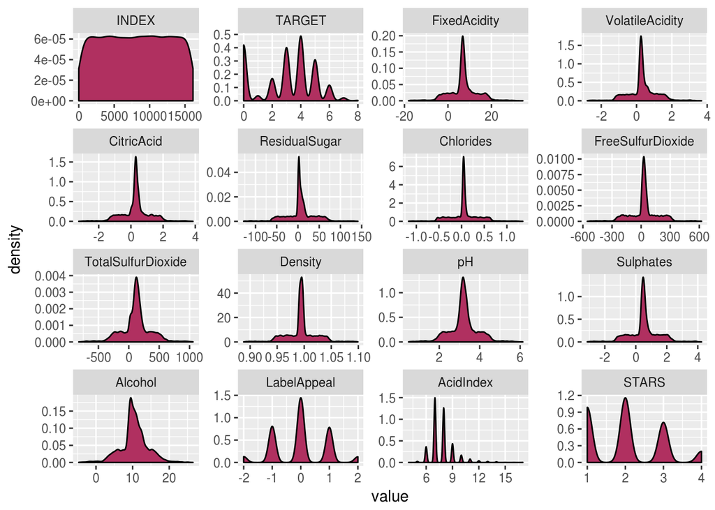

```r
#Density
par(mfrow = c(3, 3))
wine_data %>%
  melt %>%
  ggplot(aes(x= value)) +
    geom_density(fill='maroon') + facet_wrap(~variable, scales = 'free')
```

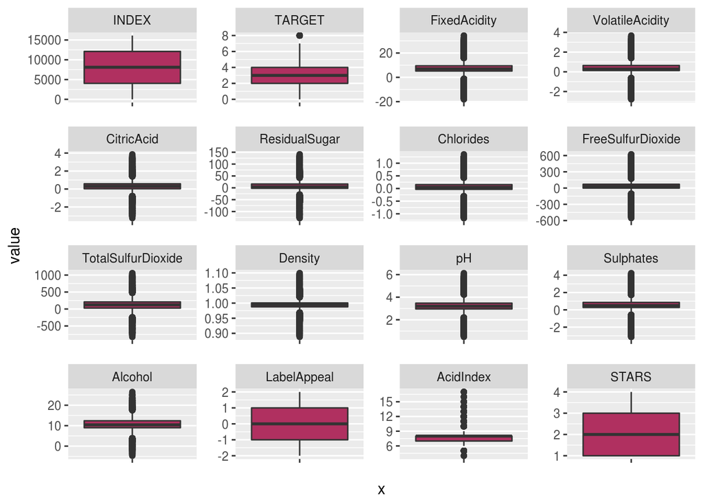

```r
#Boxplot
wine_data %>%
  melt %>%
  ggplot(mapping = aes(x= "", y = value)) +
    geom_boxplot(fill="maroon") + facet_wrap(~variable, scales = 'free')
```

```r
library(PerformanceAnalytics)
```

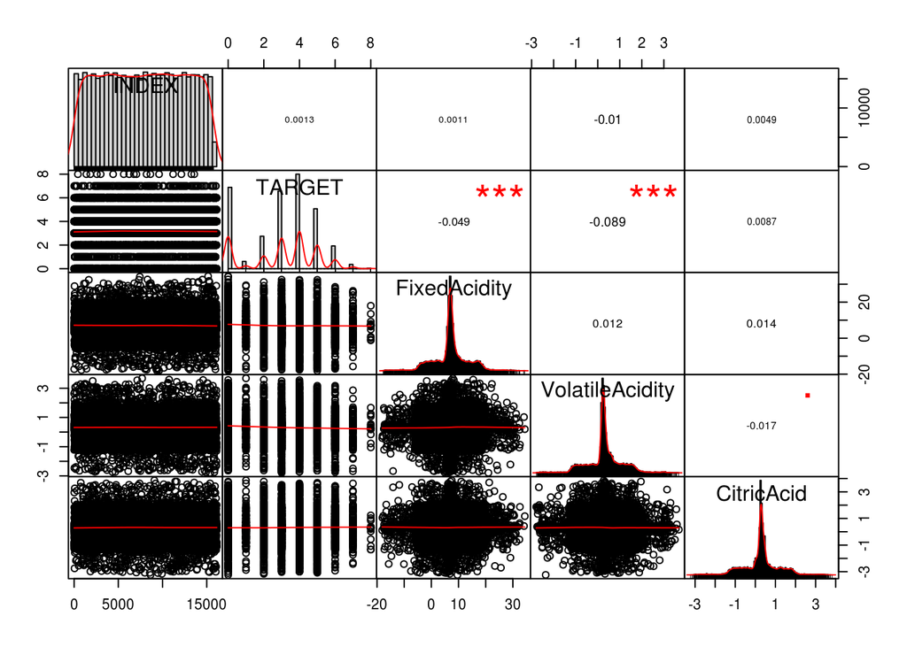

```r
par(mfrow = c(2,1))
chart.Correlation(wine_data[1:5])
```

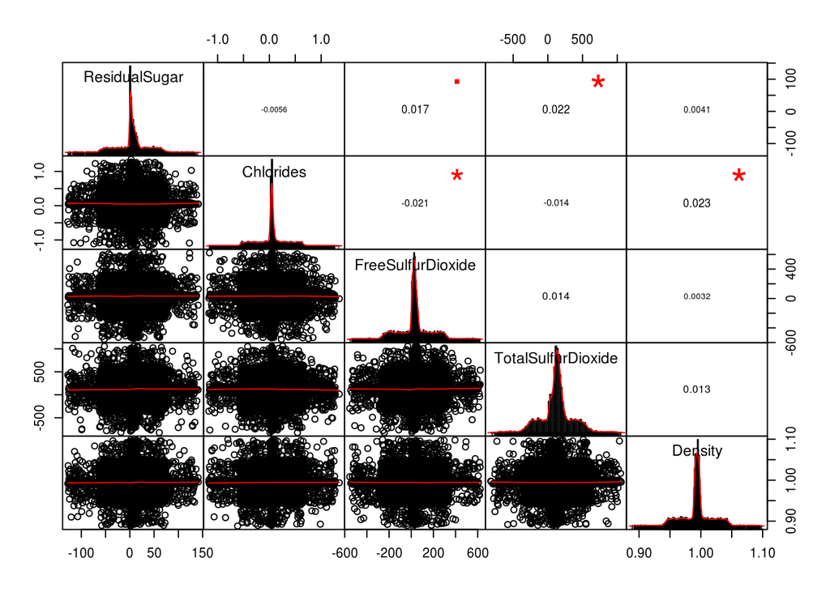

```r
chart.Correlation(wine_data[6:10])
```

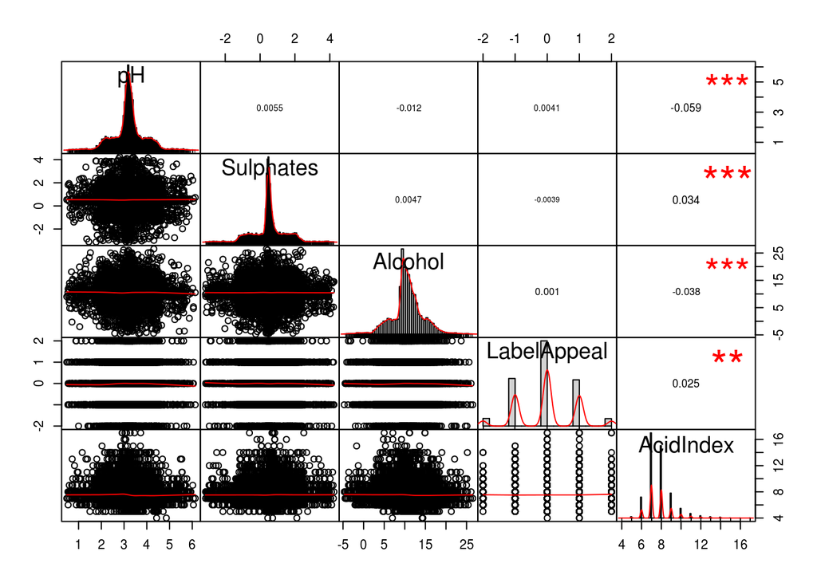

```r
chart.Correlation(wine_data[11:15])
```

[figure not shown]

```r
#library(psych)
#pairs.panels(wine_data[2:16])
library(corrplot)
corr_wine <- cor(wine_data)
corrplot(corr_wine, method = "circle")
corrplot(corr_wine, method = "number")
```

```r
get_outliers <-  function(x, n = 10) {

  v <- abs(x-mean(x,na.rm=TRUE)) > 3*sd(x,na.rm=TRUE)

  # capture all observations falling into outlier definition sort descending
  obs <- sort(unique(x[v]), decreasing = T)

  # handle cases where the number of observations is less than
  # the parameter n to return for the top and bottom n values
  if (length(obs) < 2*n) {n <- floor(length(obs)/2)}

  hi <- obs[1:n]

  low <- obs[length(obs):(length(obs)-n +1)]

  # remove duplicate entries from the lower bound outliers
  low <- setdiff(low, hi)

  return (list(Obs=obs, Hi=hi, Low=low))

}

o1 <- get_outliers(wine_data$AcidIndex)

if (length(o1[[1]])==0){
  o1 <- "none"
}
```

```r
#vifcor(wine_data)
```

```r
#plot_missing(wine_data)
```